# Interactions

Author

Affiliation

Dave Clark

Binghamton University

Published

March 23, 2025

# Multiplicative Interactions

Let’s work with the ITT data for the sake of continuity. The basic model we’re working with is predicting reports of scarring torture. In general, my argument is that scarring torture is potentially a tool regimes use to signal to dissidents they should watch themselves. Insofar as violent repression is costly, regimes will use scarring torture reduce dissent, thereby making violent repression less necessary. So when protest frequency is higher, we should see more scarring torture as regimes attempt to quell dissent.[^1]

Regime transparency will modify this relationship. Regimes that restrict access to IGOs will have lower costs for using violence (scarring torture), so should employ it at a higher rate than will regimes that do not restrict IGO access. This implies the following hypothesis:

$H_1$: *Protests will be positively related to scarring torture; their effect will be stronger in states that restrict IGO access than in states that do not.*

Alternatively, we can state it this way:

$H_1$: *Increases in protests will produce faster increases in scarring torture in states that restrict IGO access than in states that do not.*

You should note this implies two slopes - one for states that restrict IGO access, and one for states that do not. The slope effect for protests should be larger in states that restrict access.

Since we’re positing different slopes, we’re explicitly relaxing the **structural stability assumption.**

**Structural Stability**

In this regression:

$$y = \beta_0 + \beta_1 d_1 + \beta_2 x_2$$

The slope on $x_2$ is the same for both groups represented by $d_1$. The model assumes structural stability by restricting both groups in $d_1$ to have the same slope on $x_2$.

Note that the marginal effect of $x_2$ is $\beta_2$ for both groups represented by $d_1$.

We relax structural stability by adding a multiplicative interaction between $d_1$ and $x_2$. This allows the slope on $x_2$ to differ between the two groups represented by $d_1$. Note that whether or not the two groups have different slopes is now the matter of a hypothesis test.

**Multiplicative Interactions**

In this regression:

$$y = \beta_0 + \beta_1 d_1 + \beta_2 x_2 + \beta_3 (d_1x_2)$$

The slope for $x_2$ is $\beta_2$ when $d_1=0$ and $\beta_2+\beta_3$ when $d_1=1$. The interaction term, $\beta_3$, measures the difference in slopes between the two groups represented by $d_1$.

Note that interpretation of $x_2$ is now conditional on $d_1$ - we cannot interpret the effect of $x_2$ without reference to $d_1$.

## Estimating the model

Brambor, Clark, and Golder (2006) provide a great discussion of multiplicative interactions in regression models. Berry, Golder, and Milton (2012) provide further developments and particularly focus on hypotheses to test from interaction models. Recently, Clark and Golder (2023) present a comprehensive treatment of interactions in regression models (along with complete replication code). Resources for the book and articles are available on [Matt Golder’s website](https://mattgolder.com/interactions).

### Basics of interactions

A regression with the multiplicative interaction of two variables, $x_1$ and $x_2$:

- includes $x_1$ and $x_2$; these are called **constituent terms** of the interaction. Always include the constituents.
- includes a new variable $x_1 * x_2$; this is the **interaction term**.
- includes whatever other variables per usual.
- interpretation is always conditional, so we cannot interpret the effects of the constituents or interaction term without reference to the other.

Suppose the following model:

$$y = \beta_0 + \beta_1 d_1 + \beta_2 x_2 + \beta_3 (d_1x_2)$$

The expected value of $y$ for the case where $d_1=0$ is:

$$E[y|x, d_1=0] = \beta_0 + \beta_2 x_2$$

Where $d_1=1$, the expected value of $y$ is:

$$E[y|x; x|d_1=1] = \beta_0+\beta_1d_1 + \beta_2 x_2 +\beta_3 x_2d_1$$

Here, the expected value of $y$ depends on the intercept given by $\beta_0$ and $\beta_1$, *and on slopes determined by $x_2$, but those slopes differ depending on the value of $d_1$*.

**Marginal Effects**

An important insight: the interaction coefficient, $\beta_3$, measures the difference in slopes between the groups represented by $d=0$ and $d=1$.

This means the marginal effect of $x_2$ is not just $\beta_2$, but $\beta_2+\beta_3$.

## Example

Let’s look at the scarring torture model interacting protests and restricted access. The model looks like this:

$$scarring = \beta_0 + \beta_1 protests + \beta_2 restricted + \beta_3 (protests*restricted) + X\beta$$
where $X$ is a matrix of control variables.

```r
#  continuous/binary interaction ----
# now, interact protests and restricted access
itt <- read.csv("/Users/dave/Documents/teaching/501/2023/exercises/ex4/ITT/data/ITT.csv")

itt$p1 <- itt$polity2+11
itt$p2 <- itt$p1^2
itt$p3 <- itt$p1^3

itt <-
  itt%>%
  group_by(ccode) %>%
  mutate( lagprotest= lag(protest), lagRA=lag(RstrctAccess), n=1) %>%
  mutate(gdp=wdi_gdpc /1000) %>%
  mutate(pop=wdi_pop/100000) %>%
  mutate(interaction=lagprotest*RstrctAccess) %>%
  ungroup()

m4 <- lm(scarring ~  lagprotest + as.factor(RstrctAccess) +interaction +civilwar  + p1 +gdp+pop  , data=itt)

stargazer(m4, type="html",  single.row=TRUE, header=FALSE, digits=3,  omit.stat=c("LL","ser"),  star.cutoffs=c(0.05,0.01,0.001),  column.labels=c("OLS Estimates"),  dep.var.caption="Scarring Torture", dep.var.labels.include=FALSE,  covariate.labels=c("Protests, t-1", "Restricted Access","Protests (t-1)*Restricted Acc.",  "Civil War",  "Polity", "GDP per capita", "Population"),  notes=c("Standard errors in parentheses", "Significance levels:  *** p<0.001, ** p<0.01, * p<0.05"), notes.append = FALSE,  align=TRUE,  font.size="small")
```

|  | Scarring Torture |
| --- | --- |
|  | OLS Estimates |
| Protests, t-1 | 0.136 (0.074) |
| Restricted Access | 8.494*** (1.241) |
| Protests (t-1)*Restricted Acc. | 0.783*** (0.230) |
| Civil War | 7.368*** (1.549) |
| Polity | 0.036 (0.052) |
| GDP per capita | 0.009 (0.031) |
| Population | 0.001** (0.0002) |
| Constant | 4.594*** (0.769) |
| Observations | 971 |
| R<sup>2</sup> | 0.213 |
| Adjusted R<sup>2</sup> | 0.207 |
| F Statistic | 37.182*** (df = 7; 963) |
| *Note:* | Standard errors in parentheses |
|  | Significance levels: *** p<0.001, ** p<0.01, * p<0.05 |

There is no effect of *protests* on scarring torture when *restricted access* is zero. When access is restricted, the effect of *protests* on scarring torture is $\beta_1+\beta_3$ (.14+.78 = .92), so the sum of the uncondtional slope for *protests* and the interaction slope which represents the **difference in slope effect for protests between restricted and unrestricted access**.

### Inference

To say whether this is different from zero, we need to compute a standard error for the sum of these two coefficients. We can’t just add the two standard errors together, but constructing one from the variance-covariance matrix of $\beta$ is easy:

$$se(\beta_{1}+ \beta_{3})= \sqrt{var(\beta_{1})+ X_{2}^{2}var(\beta_{3})+2X_{2}cov(\beta_{1},\beta_{3})}$$
This how we’d compute the standard error for the sum of the two coefficients. Golder and his colleagues provide guidance for computing standard errors for a variety of models including two-way interactions (as above), three way interactions, and for models with quadratic terms - see the two figures below, both from [Golder’s website](https://mattgolder.com/interactions)

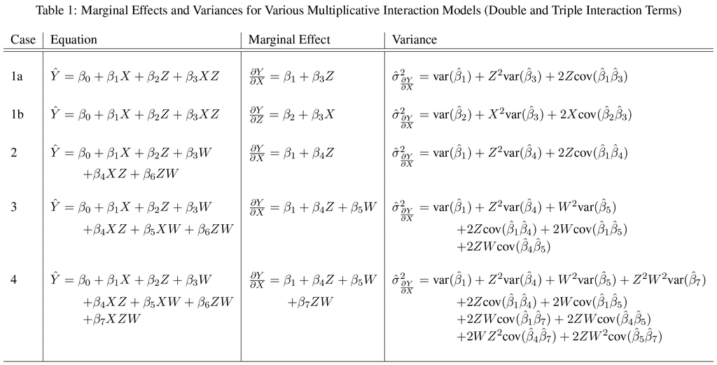

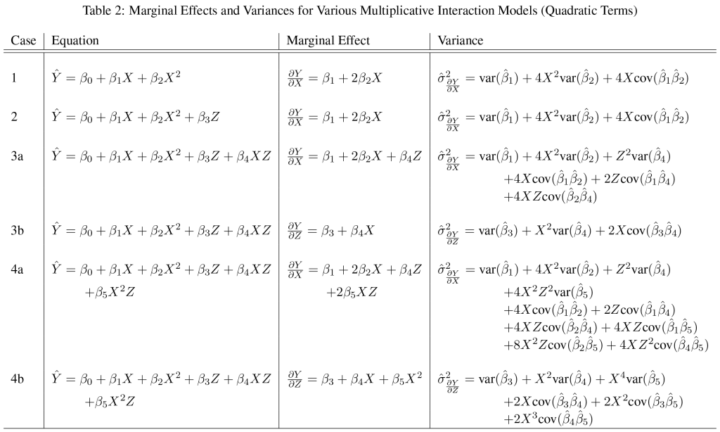

# Quantities of Interest

- linear predictions - computed as usual (using any of the methods we’ve learned, e.g, at-mean effects, average effects, simulated effects), this is a principle quantity of interest.
- We might also consider the *marginal effects* of changes in one variable on the expected value of $y$. The marginal effect is simply the change in $y$ given a change in $x$.

In the non-interactive model, the marginal effect of $x_1$ is:

$$\frac{\partial{y}}{\partial{x_{1}}}= \beta_{1}$$

In the interactive model, the marginal effect of $d_1$ is:

$$\frac{\partial{y}}{\partial{d_1}}= \beta_1+\beta_3*x_2$$

Note this depends on the values of $x_2$, allowing for the possibility the effect of $x_2$ accelerates or slows.

Interactions in regression models are symmetric in the sense that we can be interested in the effect of $d_1$ on $y$ given $x_2$ or the effect of $x_2$ on $y$ given $d_1$. Which you’re interested in is up to you and is a matter of theory.

The (symmetric) marginal effect of $x_1$ on $y$ given $d_1$ is:

$$\frac{\partial{y}}{\partial{x_2}}= \beta_2+\beta_3*d_1$$

It should make sense that if $d_1=0$, the effect is just $\beta_2$. If $d_1=1$, we adjust the slope by $\beta_3$, thereby allowing the slopes to be different for the two groups in $d_1$, relaxing structural stability. This is also a reminder that we can only interpret these coefficients conditional on one another.

## Linear Predictions (Average Effects)

Here are predictions computed as average effects for the scarring torture model. Note we have predictions for two groups (restricted and unrestricted access), and their slopes are different.

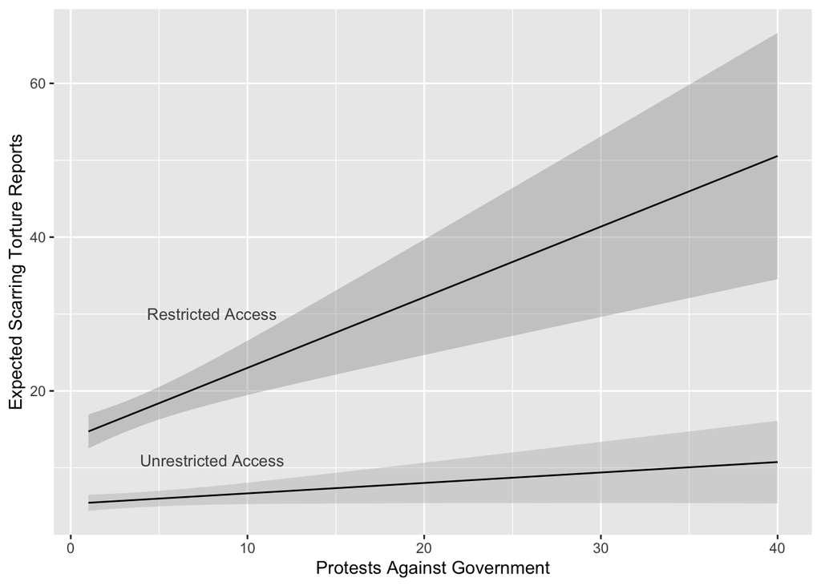

```r
# estimation sample
itt$used <- TRUE
itt$used[na.action(m4)] <- FALSE
ittesample <- itt %>%  filter(used=="TRUE")


# loop over number of protests
pred_data <-ittesample
protests <-0
medxbr0 <-0
ubxbr0 <-0
lbxbr0 <-0
medxbr1 <-0
ubxbr1 <-0
lbxbr1 <-0
pred_data$RstrctAccess <- 0
for(p in seq(1,40,1)) {
  pred_data$lagprotest <- p
  pred_data$interaction <- 0
  protests[p] <- p
  allpreds <- data.frame(predict(m4, interval="confidence", se.fit=TRUE, newdata = pred_data))
  medxbr0[p] <- median(allpreds$fit.fit, na.rm=TRUE)
  ubxbr0[p] <- median(allpreds$fit.fit, na.rm=TRUE)+1.96*(median(allpreds$se.fit, na.rm=TRUE))
  lbxbr0[p] <- median(allpreds$fit.fit, na.rm=TRUE)-1.96*(median(allpreds$se.fit, na.rm=TRUE))
}
pred_data$RstrctAccess <- 1
for(p in seq(1,40,1))  {
  pred_data$lagprotest <- p
  pred_data$interaction <- p
  allpreds <- data.frame(predict(m4, interval="confidence", se.fit=TRUE, newdata = pred_data))
  medxbr1[p] <- median(allpreds$fit.fit, na.rm=TRUE)
  ubxbr1[p] <- median(allpreds$fit.fit, na.rm=TRUE)+1.96*(median(allpreds$se.fit, na.rm=TRUE))
  lbxbr1[p] <- median(allpreds$fit.fit, na.rm=TRUE)-1.96*(median(allpreds$se.fit, na.rm=TRUE))
}

df <- data.frame(medxbr0, ubxbr0,lbxbr0,medxbr1, ubxbr1, lbxbr1, protests)


#plotting

ggplot() +
  geom_ribbon(data=df, aes(x=protests, ymin=lbxbr0, ymax=ubxbr0),fill = "grey70", alpha = .4, ) +
  geom_ribbon(data=df, aes(x=protests, ymin=lbxbr1, ymax=ubxbr1), fill= "grey60",  alpha = .4, ) +
  geom_line(data= df, aes(x=protests, y=medxbr0))+
  geom_line(data= df, aes(x=protests, y=medxbr1))+
  labs ( colour = NULL, x = "Protests Against Government", y =  "Expected Scarring Torture Reports" ) +
  annotate("text", x = 8, y = 30, label = "Restricted Access", size=3.5, colour="gray30")+
  annotate("text", x = 8, y = 11, label = "Unrestricted Access", size=3.5, colour="gray30")
```

As protests increase, we can see little change in scarring torture where IGO access is unrestricted. Transparency makes repressive acts harder to execute. On the other hand, where IGO access is restricted, scarring torture increases at considerably faster rate as protests increase. The confidence bands do not overlap, suggesting the slopes are different for the two groups.

## Marginal Effects

We can also compute the marginal effects (as above). Let’s look at the marginal effect of restricting access to IGOs on scarring torture as protests increase.[^2]

In terms of the regression above, we’re computing:

$$\frac{\partial{y}}{\partial{d_1}}= \beta_2+\beta_4*x_2$$

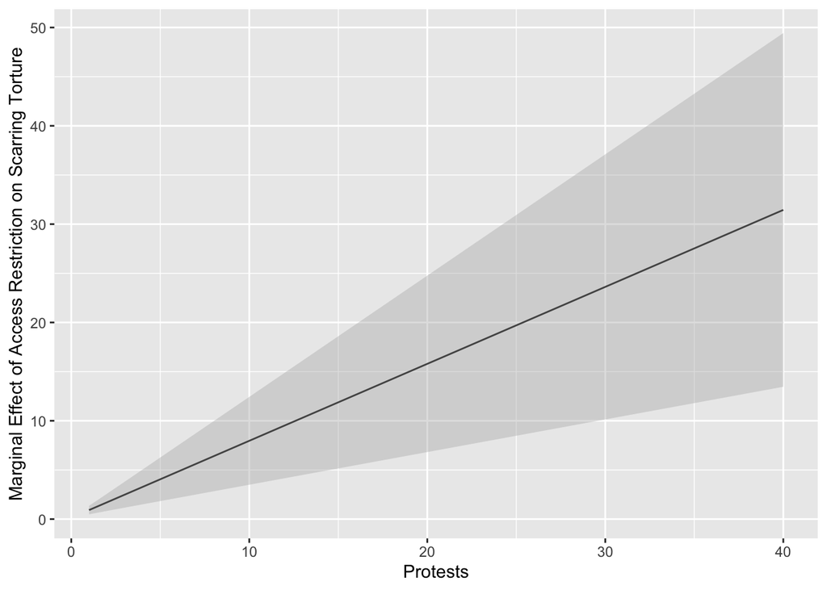

```r
df <- df %>% mutate(protest=seq(1,40,1),
  MEprotest=m4$coefficients[2]+m4$coefficients[4]*protest,
  se = sqrt(vcov(m4)[2,2]+vcov(m4)[4,4]*protest^2+2*vcov(m4)[2,4]*protest),
  ub=MEprotest+1.96*se, lb=MEprotest-1.96*se)

ggplot() +
  geom_line(data=df, aes(x=protest, y=MEprotest) ) +
  geom_ribbon(data=df, aes(x=protest, ymin=lb, ymax=ub),fill = "grey70", alpha = .4, ) +
  labs( x = "Protests", y =  "Marginal Effect of Access Restriction on Scarring Torture")
```

## References

Berry, William D, Matt Golder, and Daniel Milton. 2012. “Improving Tests of Theories Positing Interaction.” *Journal of Politics* 74 (3): 653–71.

Brambor, T., W. R. Clark, and M. Golder. 2006. “Understanding Interaction Models: Improving Empirical Analyses.” *Political Analysis* 14 (1): 63–82.

Clark, William Roberts, and Matt Golder. 2023. *Interaction Models: Specification and Interpretation*. Cambridge University Press.

Back to top

## Footnotes

[^1]: It should be evident my argument implies both that protests influence scarring torture and that torture shapes protests; this simultaneity, if it exists, means the estimates are both biased an inefficient, and we should find a way to model this interesting source endogeneity. We’ll do so in week 15.
[^2]: Since restricted access is binary, this is really a first difference rather than a marginal effect.